# `Ellipses` Ellipses, Data Ellipses, and Confidence Ellipses

Kevin O Brien

21 November 2018

#### Description

These functions draw ellipses, including data ellipses, and confidence ellipses for linear, generalized linear, and possibly other models.

#### Usage

[output not shown]

#### Arguments

center 2-element vector with coordinates of center of ellipse. shape 2 _ 2 shape (or covariance) matrix. radius radius of circle generating the ellipse. log when an ellipse is to be added to an existing plot, indicates whether computations were on logged values and to be plotted on logged axes; “x” if the x-axis is logged, “y” if the y-axis is logged, and “xy” or “yx” if both axes are logged. The default is “”, indicating that neither axis is logged. center.pch character for plotting ellipse center; if FALSE or NULL the center point isn’t plotted. center.cex relative size of character for plotting ellipse center. segments number of line-segments used to draw ellipse. draw if TRUE produce graphical output; if FALSE, only invisibly return coordinates of ellipse(s).

add if TRUE add ellipse(s) to current plot. * `xlab` label for horizontal axis. * `ylab` label for vertical axis. * `x` a numeric vector, or (if y is missing) a 2-column numeric matrix. * `y` a numeric vector, of the same length as x. * `groups` optional: a factor to divide the data into groups; a separate ellipse will be plotted for each group (level of the factor). * `group.label`s labels to be plotted for the groups; by default, the levels of the groups factor. * `ellipse.label` a label for the ellipse(s) or a vector of labels; if several ellipses are drawn and just one label is given, then that label will be repeated. The default is not to label the ellipses. * `weights` a numeric vector of weights, of the same length as x and y to be used by cov.wt or cov.trob in computing a weighted covariance matrix; if absent, weights of 1 are used. plot.points if FALSE data ellipses are drawn, but points are not plotted. * `levels` draw elliptical contours at these (normal) probability or confidence levels. * `robust` if TRUE use the cov.trob function in the MASS package to calculate the center and covariance matrix for the data ellipse. * model a model object produced by lm or glm. * `which.coef` 2-element vector giving indices of coefficients to plot; if missing, the first two coefficients (disregarding the regression constant) will be selected.

- `vcov.` a coefficient-covariance matrix or a function (such as hccm) to compute the coefficent-covariance matrix from model; the default is the vcov function. L As an alternative to selecting coefficients to plot, a transformation matrix can be specified to compute two linear combinations of the coefficients; if the L matrix is given, it takes precedence over the which.coef argument. L should have two rows and as many columns as there are coefficients. It can be given directly as a numeric matrix, or specified by a pair of character-valued expressions, in the same manner as for the link{linearHypothesis} function, but with no right-hand side.
- `Scheffe` if TRUE scale the ellipse so that its projections onto the axes give Scheffe confidence intervals for the coefficients.
- `dfn` “numerator” degrees of freedom (or just degrees of freedom for a GLM) for drawing the confidence ellipse. Defaults to the number of coefficients in the model (disregarding the constant) if Scheffe is TRUE, or to 2 otherwise; selecting dfn = 1 will draw the “confidence-interval generating” ellipse, with projections on the axes corresponding to individual confidence intervals with the stated level of coverage.
- `chisq` if TRUE, the confidence ellipse for the coefficients in a generalized linear model are based on the chisquare statistic, if FALSE on the $F$-statistic. This corresponds to using the default and linear-model methods respectively.
- `col` color for lines and ellipse center; the default is the second entry in the current car palette (see carPalette and par). For dataEllipse, two colors can be given, in which case the first is for plotted points and the second for lines and the ellipse center; if ellipses are plotted for groups, then this is a vector of colors for the groups. pch for dataEllipse this is the plotting character (default, symbol 1, a hollow circle) to use for the points; if ellipses are plotted by groups, then this a vector of plotting characters, with consecutive symbols starting with 1 as the default. lwd line width; default is 2 (see par).
- fill fill the ellipse with translucent color col (default, FALSE)?
- fill.alpha transparency of fill (default = 0.3).
- … other plotting parameters to be passed to plot and line.
- id controls point identification; if FALSE (the default), no points are identified; can be a list of named arguments to the showLabels function; TRUE is equivalent to list(method=“mahal”, n=2, cex=1, col=carPalette()[1], location=“lr”) (with the default col actually dependent on the number of groups), which identifies the 2 points with the largest Mahalanobis distances from the center of the data.
- `grid`: If TRUE, the default, a light-gray background grid is put on the graph

#### Examples

```r
dataEllipse(Duncan$income, Duncan$education, levels=0.1*1:9,
ellipse.label=0.1*1:9, lty=2, fill=TRUE, fill.alpha=0.1)
```

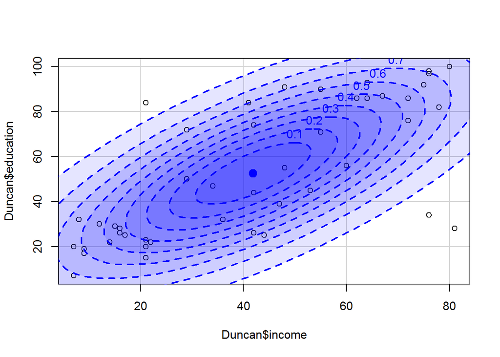

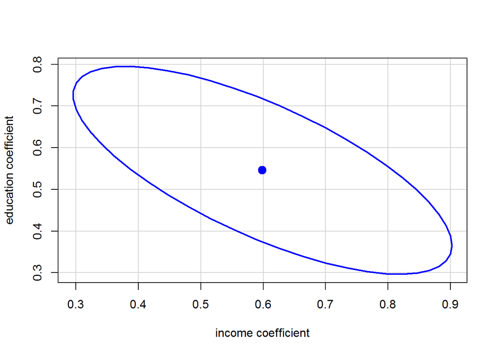

```r
confidenceEllipse(lm(prestige~income+education, data=Duncan), Scheffe=TRUE)
```

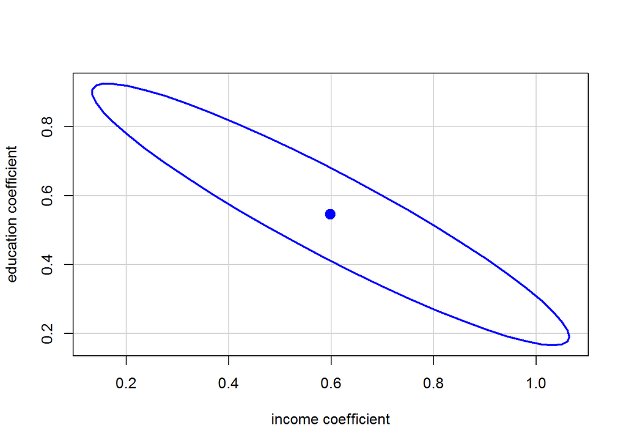

```r
confidenceEllipse(lm(prestige~income+education, data=Duncan), vcov.=hccm)
```

```r
confidenceEllipse(lm(prestige~income+education, data=Duncan),
L=c("income + education", "income - education"))
```

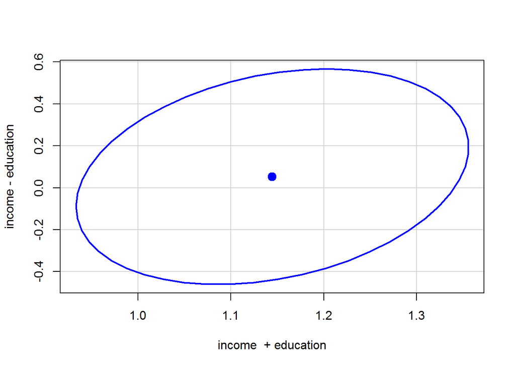

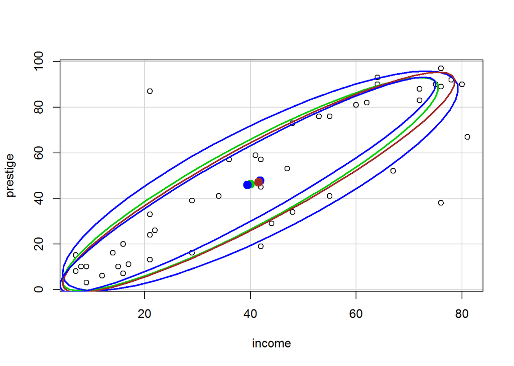

```r
wts <- rep(1, nrow(Duncan))
wts[c(6, 16)] <- 0 # delete Minister, Conductor
with(Duncan, {
dataEllipse(income, prestige, levels=0.68)
dataEllipse(income, prestige, levels=0.68, robust=TRUE,
plot.points=FALSE, col="green3")
dataEllipse(income, prestige, weights=wts, levels=0.68,
plot.points=FALSE, col="brown")
dataEllipse(income, prestige, weights=wts, robust=TRUE, levels=0.68,
plot.points=FALSE, col="blue")
})
```

```r
with(Prestige, dataEllipse(income, education, type,
id=list(n=2, labels=rownames(Prestige)), pch=15:17,
xlim=c(0, 25000), center.pch="+",
group.labels=c("Blue Collar", "Professional", "White Collar"),
ylim=c(5, 20), level=.95, fill=TRUE, fill.alpha=0.1))
```

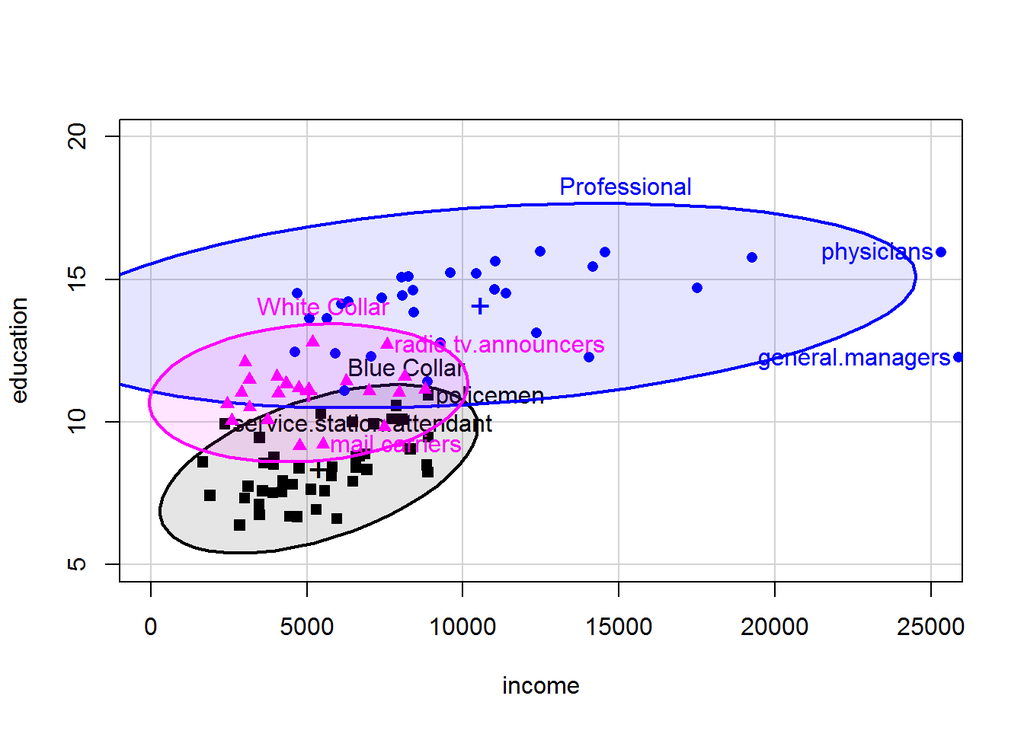

#### Details

The ellipse is computed by suitably transforming a unit circle. dataEllipse superimposes the normal-probability contours over a scatterplot of the data. Value These functions are mainly used for their side effect of producing plots. For greater flexibility (e.g., adding plot annotations), however, ellipse returns invisibly the (x, y) coordinates of the calculated ellipse. dataEllipse and confidenceEllipse return invisibly the coordinates of one or more ellipses, in the latter instance a list named by levels. Author(s) Georges Monette, John Fox jfox@mcmaster.ca, and Michael Friendly.

#### References

Fox, J. (2016) Applied Regression Analysis and Generalized Linear Models, Third Edition. Sage. Fox, J. and Weisberg, S. (2019) An R Companion to Applied Regression, Third Edition, Sage. Monette, G. (1990) Geometry of multiple regression and 3D graphics. In Fox, J. and Long, J. S. (Eds.) Modern Methods of Data Analysis. Sage. See Also cov.trob, cov.wt, linearHypothesis. Export 53